# XGBoost predict RNA modification class

Author

Kyle Palos

Published

March 3, 2023

## Overview

ModTect reports more modifications than HAMR does, but does not predict the type of modification, HAMR does.

Because these 2 tools are based on very similar premises, I think that ModTect output can be trained on HAMR output to predict modification class.

### Load packages

```r
library(dplyr)
library(tidyr)
library(ggplot2)
library(data.table)
library(tidymodels)
library(readr)
library(vroom)
```

### Load in data

```r
# this is ModTect output from Maize RNA-seq
# Specifically, this is the output after performing bedtools intersect against a bed file of Maize genes
modtect <- vroom("/mnt/Milly/Work/Sorghum_epitranscriptomics_project/Sorghum_seq_third_replacement_round/modeling_hamr/combined_zm.txt",
                 col_names = F)

# Make a smaller data frame that I can put onto GitHub so people can follow along
modtect1k <- modtect %>%
  slice_sample(n = 1000)

# write.table(modtect1k,
#             "zm_modtect_sample_file.txt",
#             sep = "\t", quote = F, row.names = F, col.names = F)


# This is the ModTect header
header <- read_delim("/mnt/Milly/Work/Sorghum_epitranscriptomics_project/Sorghum_seq_third_replacement_round/modeling_hamr/modtect_header.txt",
    delim = "\t", escape_double = FALSE,
    trim_ws = TRUE)


# set the header as the column names for ModTect
colnames(modtect) <- colnames(header)

# rename columns and get rid of some unnecessary columns
modtect <- modtect %>% rename(tx_chr = 34, tx_start = 35, tx_end = 36, gene = 37, overlap = 38, file = 39) %>%
  select(-5,-6,-7,-8)

# get rid of input file name (there are many experiments of ModTect that have concatenated into 1 input file)
modtect$file <- gsub('_intersected.txt', '', modtect$file)

# filter for high coverage sights and make each combination of chromosome and site a combined column so we have unique site identifiers.


modtect %>%
  select(-overlap) %>%
  distinct() %>%
  unite("full_position",
        1:3,
        sep = "_") %>%
  filter(depth >= 10) %>%
    mutate(sum_upper = rowSums(.[13:16]), # sum the counts coming from the forward and reverse strands to determine if there is a strand bias
         sum_lower = rowSums((.[17:20]))) -> modtect
```

### Load in HAMR datasets

HAMR used a KNN model to predict RNA modifications based on Yeast tRNA reverse-transcriptase error profiles. I don’t have that original Yeast data but I will model ModTect error profiles on HAMR classifications to get predicted modification class.

```r
# Maize HAMR output
zm1_hm <- read_delim("/mnt/Milly/Work/Sorghum_epitranscriptomics_project/Sorghum_seq_third_replacement_round/modeling_hamr/zm1.mods.txt",
    delim = "\t", escape_double = FALSE,
    trim_ws = TRUE)

# filter for relevant columns and generate a variant proportion column that ModTect directly reports
zm1_hm %>%
  select(4:10, 16) %>%
  mutate(variant_proportion = (nonref / (nonref + ref))) %>%
  select(-nonref, -ref) -> zm1_hm
```

### Data cleaning

Get the ModTect data in a similar format as the HAMR data for modeling purposes.

```r
modtect %>%
  select(1:3, 13:20) %>% # select relevant columns
  rowid_to_column(var = "rowid") -> modtect2

modtect2 %>%
  select(-full_position) %>% # full position is not a meaningful column to predict on so remove it for now
  column_to_rownames(var = "rowid") %>%
  mutate(A = A_count + a_count, # combine nucleotide counts from opposite strands
         "T" = T_count + t_count,
         C = C_count + c_count,
         G = G_count + g_count) %>%
  select(-A_count, -T_count, -C_count, -G_count,
         -a_count, -t_count, -c_count, -g_count) %>%
  rename(refnuc = 1) %>%
  select(1,3,5,6,4,2) -> modtect2

# rearrange columns
zm1_hm %>%
  select(1,2,3,4,5,7,6) -> zm1_hm

# change character columns to factor
zm1_hm$pred.mod <- as.factor(zm1_hm$pred.mod)
zm1_hm$refnuc <- as.factor(zm1_hm$refnuc)

# similarly for ModTect
modtect2$refnuc <- as.factor(modtect2$refnuc)

zm1_hm %>%
  mutate(pred.mod2 = case_when(pred.mod == "m1A|m1I|ms2i6A" ~ "m1A",
                              pred.mod == "i6A|t6A" ~ "i6A",
                              pred.mod == "D" ~ "D",
                              pred.mod == "Y" ~ "Y",
                              pred.mod == "m1G" ~ "m1G",
                              pred.mod == "m2G|m22G" ~ "m2G",
                              pred.mod == "m3C" ~ "m3C")) %>% # simplify modification nomenclature
  select(-pred.mod) %>%
  rename(pred.mod = pred.mod2) -> zm1_hm

# change this modification to a factor
zm1_hm$pred.mod <- as.factor(zm1_hm$pred.mod)
```

HAMR data is ready for developing a model

I am going to use xgboost because I have a lot of data and it works well out of the box

Takes a lot of hyperparameter tuning though

Going to follow along with Julia Silge’s tutorial for using xgboost in classification on volleyball winning data [here](https://www.youtube.com/watch?v=hpudxAmxHSM&t=106s)

Split the data and stratify for pred.mod because it is imbalanced (there is a lot less m2G compared to m1A and m3C)

### Begin modeling

```r
set.seed(123)

hm_split <- initial_split(zm1_hm, strata = pred.mod) # Perform the initial data split, stratifying based on our desred outcome (predicted modification)

# split into training and testing using default 70/30 split
hm_training <- training(hm_split)
hm_test <- testing(hm_split)
```

Specify that we are going to use boosting classification trees

And that we basically want the computer to find the optimal values for all the important hyper-parameters

```r
xgb_spec <- boost_tree(
  trees = 1000,
  tree_depth = tune(), min_n = tune(), loss_reduction = tune(),
  sample_size = tune(), mtry = tune(), learn_rate = tune()
) %>%
  set_engine("xgboost") %>%
  set_mode("classification")
```

But what values do we even want it to try?

Well, grid latin hypercube generates near-random sequences that usually covers your “data space” more equally than other methods

```r
xgb_grid <- grid_latin_hypercube(
  tree_depth(),
  min_n(),
  loss_reduction(),
  sample_size = sample_prop(),
  finalize(mtry(), hm_training),
  learn_rate(),
  size = 30
)
```

Specify our workflow

Basically, we are going to predict modification class based on all input data

```r
xgb_wf <- workflow() %>%
  add_formula(pred.mod ~ .) %>%
  add_model(xgb_spec)
```

V fold cross validation randomly splits the training data into roughly equal sized groups (folds).

V-fold CV essentially performs the training-test split multiple times and allows for more accurate model generation

```r
set.seed(123)

hm_folds <- vfold_cv(hm_training, strata = pred.mod)
```

Set up multiple computing nodes and begin to perform the grid tuning (hyper-parameter selection) and modeling

```r
doParallel::registerDoParallel()

set.seed(234)

xgb_res <- tune_grid(
  xgb_wf,
  resamples = hm_folds,
  grid = xgb_grid,
  control = control_grid(save_pred = TRUE)
)
```

### Evaluate model performance:

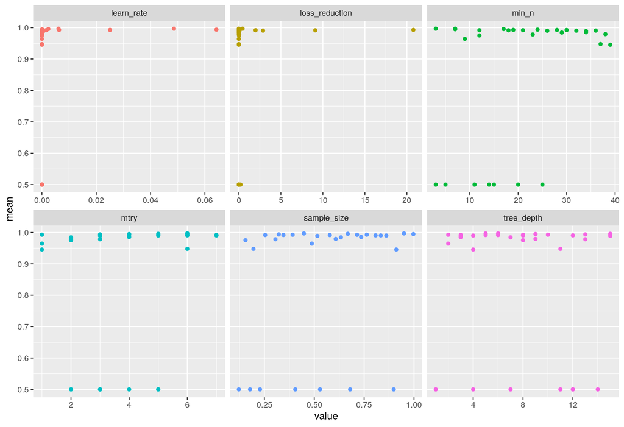

```r
xgb_res %>%
  collect_metrics() %>%
  filter(.metric == "roc_auc") %>%
  select(mean, mtry:sample_size) %>%
  pivot_longer(mtry:sample_size, # reshape the data for better graphing
               names_to = "parameter",
               values_to = "value") %>%
  ggplot(aes(x = value, y = mean, color = parameter)) +
  geom_point(show.legend = F) +
  facet_wrap(~parameter, scales = "free_x")
```

y-axis values are the area under the curve values

higher learn rates and loss reductions boost model performance. Other parameters are less linearly associated with performance.

```r
show_best(xgb_res, "roc_auc") %>% view()
```

Select the best model by classifier performance

```r
best_auc <- select_best(xgb_res, "roc_auc")
```

Now we need to finalize the workflow

```r
final_xgb <- finalize_workflow(xgb_wf, best_auc)
```

The final model now has the exact hyper-parameters

What were the biggest contributors to the classification?

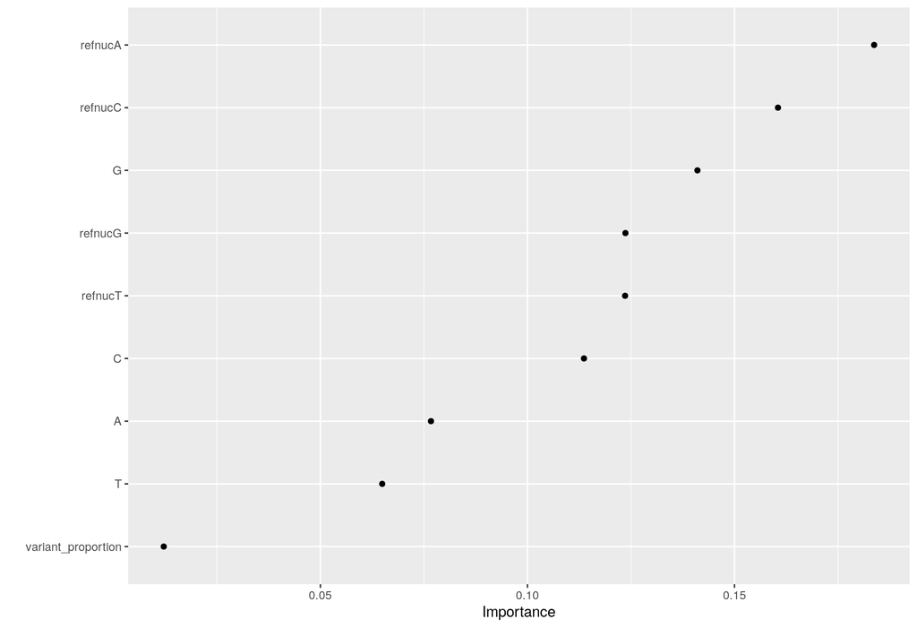

```r
library(vip)

final_xgb %>%
  fit(data = hm_training) %>%
  pull_workflow_fit() %>%
  vip(geom = "point")
```

Sort of as expected, the reference nucleotide, and the mutated nucleotide profiles are the biggest importance in this model.

Make a confusion matrix

```r
final_result <- last_fit(final_xgb, hm_split)
final_result %>%
  collect_metrics()
```

```
# A tibble: 2 × 4
  .metric  .estimator .estimate .config
  <chr>    <chr>          <dbl> <chr>
1 accuracy multiclass     0.972 Preprocessor1_Model1
2 roc_auc  hand_till      0.999 Preprocessor1_Model1
```

```r
final_result %>%
  collect_predictions() %>%
  conf_mat(pred.mod, .pred_class)
```

```
          Truth
Prediction   D i6A m1A m1G m2G m3C   Y
       D   256   0   0   0   0   0  12
       i6A   0 359  21   0   0   0   0
       m1A   0  16 529   0   0   0   0
       m1G   0   0   0 316   6   0   0
       m2G   0   0   0   4  53   0   0
       m3C   0   0   0   0   0 525   0
       Y     4   0   0   0   0   0 165
```

### Model on any new data

Using the input ModTect data

```r
final_result %>%
  extract_workflow() %>%
  predict(modtect2) -> zm2_mods

modtect %>%
  select(1:3, 13:20) %>%
  rowid_to_column(var = "rowid") -> modtect3

modtect3$rowid <- as.character(modtect3$rowid)


zm2_mods %>%
  rownames_to_column(var = "row") %>%
  rename(pred.mod = 2) %>%
  left_join(modtect3, ., by = c("rowid" = "row")) %>%
  select(full_position, pred.mod) %>%
  distinct() -> predicted.mods

# write_delim(predicted.mods, "zm_predicted_modtect_mods.txt",
#             delim = "\t")
```